# Reproducible Research. Assignment 1

Mauro Gatti

Sunday, August 17, 2014

*Summary This document provides a concise analysis of the Activity monitoring data set

*Prerequisites The activity.csv file that will be analized has to be available. You will need to modify the path of the directory in the setwd command below according to your file system structure. The next commands reads the file data.

```r
#Work directory
setwd("C:\\User\\Courses\\ReproducibleResearch\\MyAssignments\\Assignment1")

#Read data
fileName<-"activity.csv"
columnNames<-c("steps", "date","interval")
data<-read.table(fileName,sep=",",stringsAsFactor=FALSE,header=TRUE,
               na.strings=c("NA", " "),col.names=columnNames)
```

The next block of instructions reorganizes the datasets. They are not strictly required.

```r
#Create steps dataset
stepsByTimeData<-data.frame(data$date,data$steps)
colnames(stepsByTimeData)<-c("date","steps")
stepsByIntervalData<-data.frame(data$interval,data$steps)
colnames(stepsByIntervalData)<-c("interval","steps")
stepsByTimeNotNullBinaryData<-!is.na(stepsByTimeData$steps)
stepsByTimeNotNullData<-stepsByTimeData$steps[stepsByTimeNotNullBinaryData]
stepsByIntervalNotNullBinaryData<-!is.na(stepsByIntervalData$steps)
stepsByIntervalNotNullData<-stepsByIntervalData$steps[stepsByIntervalNotNullBinaryData]
```

The next plot shows the distribution of steps by day:

```r
#Aggregate steps by day
library(zoo)
```

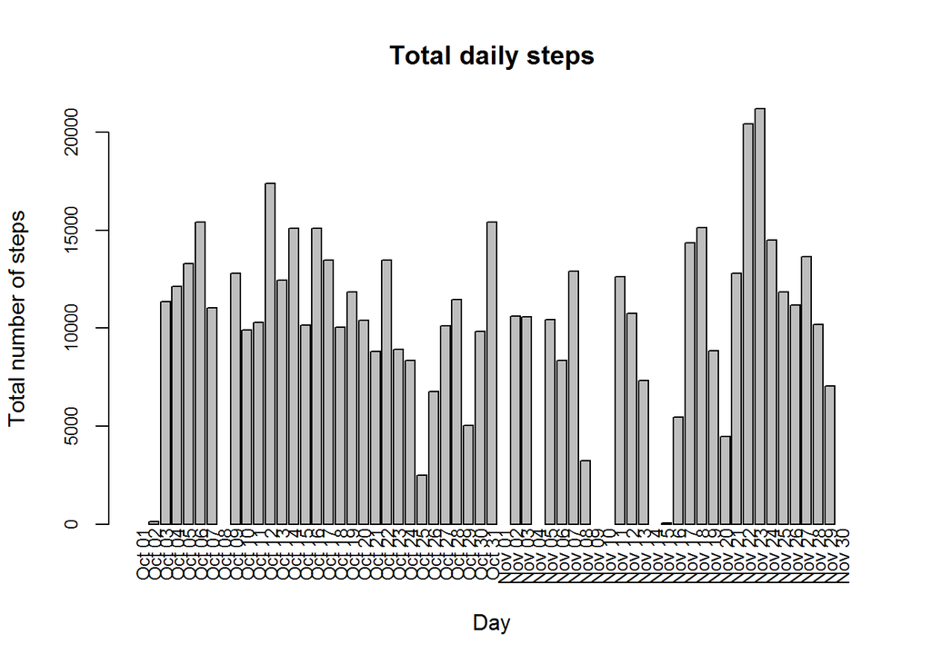

```r
statsum <- function(x) c(sum=sum(x,na.RM=TRUE))
stepsByTimeSum <- read.zoo(stepsByTimeData, header = TRUE, sep = ",", format="%Y-%m-%d", aggregate = statsum)

#Histogram of total steps per day
bp<-barplot(stepsByTimeSum, main="Total daily steps",xlab="Day",ylab="Total number of steps",horiz=FALSE,axes=FALSE,axisnames=FALSE)
axis(2,cex.axis=0.8)
text(bp, par("usr")[3], labels = format(index(stepsByTimeSum), format="%b %d"), srt = 90, adj = 1, xpd = TRUE,cex=0.8)
```

Similar instructions can be used to see the mean and median:

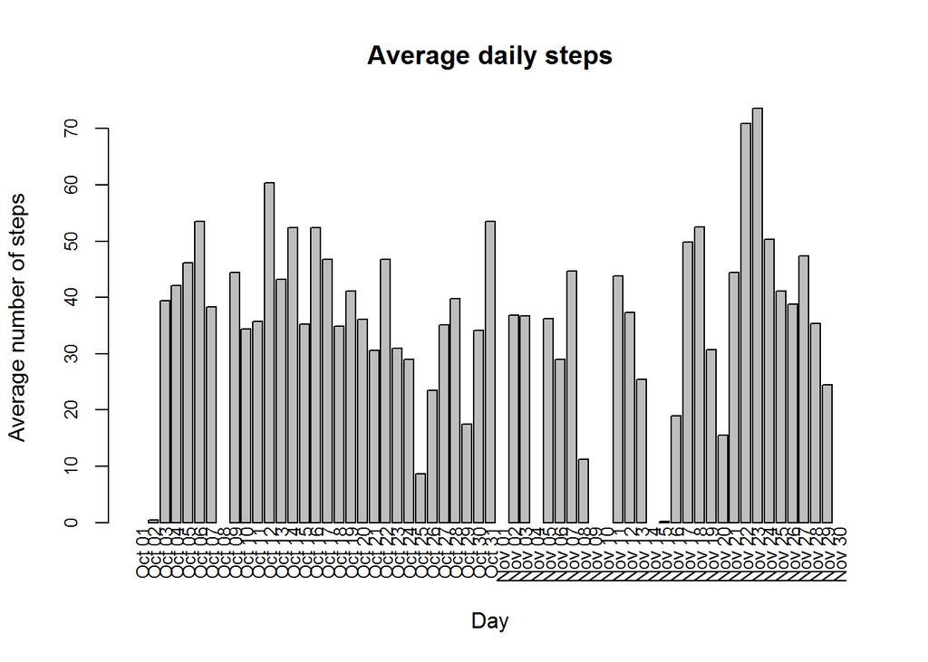

```r
#Average number of steps by day
library(zoo)
statmean <- function(x) c(mean = mean(x,na.rm=TRUE))
stepsByTimeMean <- read.zoo(stepsByTimeData, header = TRUE, sep = ",", format="%Y-%m-%d", aggregate = statmean)

#Histogram of average steps per day
bp<-barplot(stepsByTimeMean, main="Average daily steps",xlab="Day",ylab="Average number of steps",horiz=FALSE,axes=FALSE,axisnames=FALSE)
axis(2,cex.axis=0.8)
text(bp, par("usr")[3], labels = format(index(stepsByTimeMean), format="%b %d"), srt = 90, adj = 1, xpd = TRUE,cex=0.8)
```

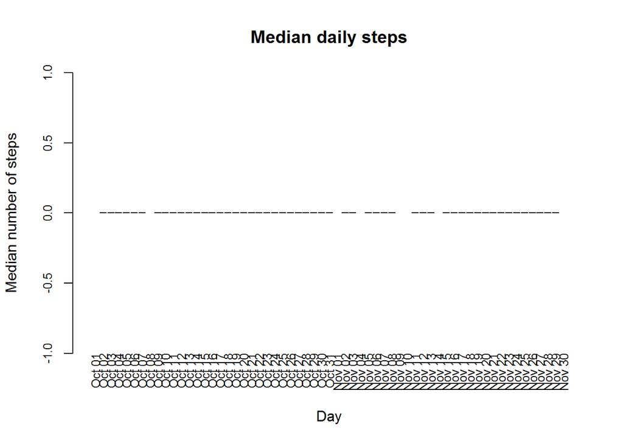

```r
#Median of daily steps
library(zoo)
statmedian <- function(x) c(median = median(coredata(x),na.rm=TRUE))
stepsByTimeMedian <- read.zoo(stepsByTimeData, header = TRUE, sep = ",", format="%Y-%m-%d", aggregate = statmedian)

#Histogram of median steps per day
bp<-barplot(stepsByTimeMedian, main="Median daily steps",xlab="Day",ylab="Median number of steps",horiz=FALSE,axes=FALSE,axisnames=FALSE)
axis(2,cex.axis=0.8)
text(bp, par("usr")[3], labels = format(index(stepsByTimeMedian), format="%b %d"), srt = 90, adj = 1, xpd = TRUE,cex=0.8)
```

Rather than using the day we can use the 5-minute interval and we obtain the following barplot:

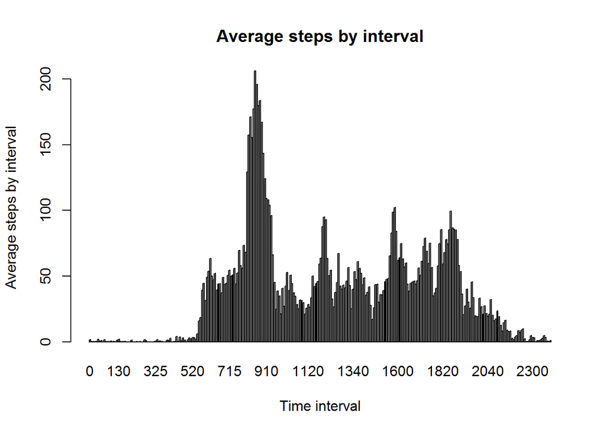

```r
#Aggregate data by 5-minute interval
library(zoo)
statmean <- function(x) c(mean = mean(x,na.rm=TRUE))
stepsByIntervalMean <- read.zoo(stepsByIntervalData, header = TRUE, sep = ",",  aggregate = statmean)

#Histogram of average steps per day
barplot(stepsByIntervalMean, main="Average steps by interval",xlab="Time interval",ylab="Average steps by interval",horiz=FALSE)
```

We can easily identify the maximum point as follows:

```r
#Maximum interval
maxIntervalPosition<-which.max(stepsByIntervalMean)
stepsByIntervalMean[maxIntervalPosition]
```

```
##   835
## 206.2
```

The dataset contains several null values. The exact number can be obtained with the following command:

```r
#Number of rows with missing values
sum(is.na(data))
```

```
## [1] 2304
```

```r
sum(is.na(data$steps)) #All missing values are in the steps column
```

```
## [1] 2304
```

We want to replace the NA values with something meaningful and we decide to replace it with the average of the not NA values surroung the NA value. For such a purpose we use the following function:

```r
#Cleans missing values by using local average of not null data
cleanMissingValues = function(x,k) {
        ind = which(is.na(x))
        for(i in ind){
                if(i-k>0 & i+k<length(x)){
                        x[i]<-mean(x[seq(i-k,i+k,1)],na.rm=TRUE)
                }
                else if(i-k<=0 & i+k<length(x))
                {
                        x[i]<-mean(x[seq(0,i+k+1,1)],na.rm=TRUE)
                }
                else if(i-k>0 & i+k>=length(x))
                {
                        x[i]<-mean(x[seq(i-k,length(x),1)],na.rm=TRUE)
                }
                else if(i-k<=0 & i+k>=length(x))
                {
                        x[i]<-mean(x[seq(0,length(x),1)],na.rm=TRUE)
                }
                else
                {
                        x[i]<-mean(x[seq(0,length(x),1)],na.rm=TRUE)
                }
        }
        x[!ind]<-x
        return (x)
}
```

```r
#Cleaned data set
cleanData<-data
cleanData$steps = cleanMissingValues(data$steps,10)
stepsByTimeDataClean<-data.frame(data$date,data$steps)
colnames(stepsByTimeDataClean)<-c("date","steps")
```

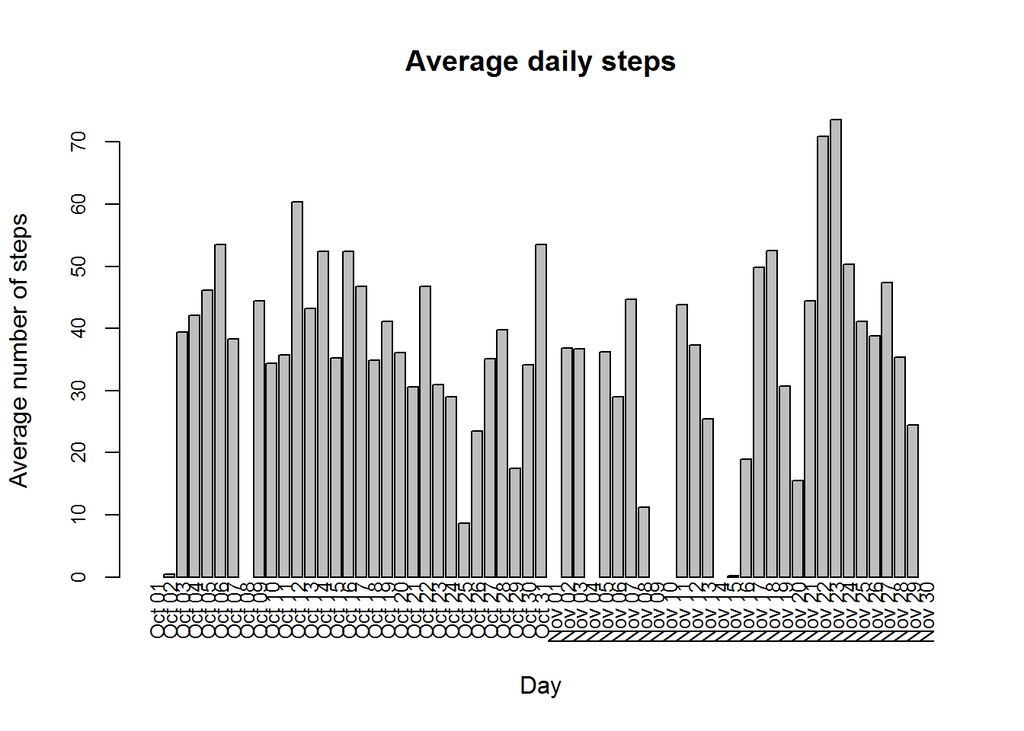

```r
#Average number of steps by day
library(zoo)
statmean <- function(x) c(mean = mean(x,na.rm=TRUE))
stepsByTimeMeanClean <- read.zoo(stepsByTimeDataClean, header = TRUE, sep = ",", format="%Y-%m-%d", aggregate = statmean)

#Histogram of average steps per day
bp<-barplot(stepsByTimeMeanClean, main="Average daily steps",xlab="Day",ylab="Average number of steps",horiz=FALSE,axes=FALSE,axisnames=FALSE)
axis(2,cex.axis=0.8)
text(bp, par("usr")[3], labels = format(index(stepsByTimeMeanClean), format="%b %d"), srt = 90, adj = 1, xpd = TRUE,cex=0.8)
```